# Exercise on First Fundamental Assumption of Inferential Methods

Amirali Satvati

```r
data <- read.csv(choose.files())
```

# Introduction

In this exercise, the data related to a study investigating the effect of daily study hours on GPA is analyzed. The primary goal is to determine the relationship between study hours (independent variable) and GPA (dependent variable) and test for normality of the residuals.

```r
asmstu <- data[sample(1:nrow(data), 50),]
head(asmstu)
```

```
##      Student_ID Study_Hours_Per_Day Extracurricular_Hours_Per_Day
## 1602       1602                 6.8                           1.8
## 1013       1013                 7.3                           2.4
## 104         104                 7.6                           3.1
## 1782       1782                 9.4                           0.8
## 147         147                 6.7                           3.3
## 276         276                 7.5                           2.5
##      Sleep_Hours_Per_Day Social_Hours_Per_Day Physical_Activity_Hours_Per_Day
## 1602                 5.7                  0.3                             9.4
## 1013                 7.1                  0.2                             7.0
## 104                  7.6                  4.9                             0.8
## 1782                 5.4                  4.7                             3.7
## 147                  5.6                  5.1                             3.3
## 276                  9.3                  2.7                             2.0
##       GPA Stress_Level
## 1602 3.01         High
## 1013 3.17     Moderate
## 104  2.99     Moderate
## 1782 3.25         High
## 147  2.95         High
## 276  3.20     Moderate
```

```r
model <- lm(GPA ~ Study_Hours_Per_Day, data = data)
stuGR <- model$res
head(summary(asmstu))
```

```
##    Student_ID     Study_Hours_Per_Day Extracurricular_Hours_Per_Day
##  Min.   :  35.0   Min.   :5.400       Min.   :0.000
##  1st Qu.: 482.8   1st Qu.:6.625       1st Qu.:0.950
##  Median :1019.5   Median :7.600       Median :1.800
##  Mean   : 954.4   Mean   :7.620       Mean   :1.874
##  3rd Qu.:1414.2   3rd Qu.:8.550       3rd Qu.:2.750
##  Max.   :1943.0   Max.   :9.700       Max.   :3.900
##  Sleep_Hours_Per_Day Social_Hours_Per_Day Physical_Activity_Hours_Per_Day
##  Min.   :5.100       Min.   :0.100        Min.   :0.400
##  1st Qu.:6.000       1st Qu.:1.100        1st Qu.:2.700
##  Median :7.000       Median :2.700        Median :4.100
##  Mean   :7.232       Mean   :2.736        Mean   :4.538
##  3rd Qu.:8.500       3rd Qu.:4.275        3rd Qu.:6.375
##  Max.   :9.800       Max.   :6.000        Max.   :9.700
##       GPA        Stress_Level
##  Min.   :2.500   Length:50
##  1st Qu.:2.990   Class :character
##  Median :3.180   Mode  :character
##  Mean   :3.164
##  3rd Qu.:3.370
##  Max.   :3.690
```

# First Fundamental Assumption

It is assumed that the relationship between the independent and dependent variables is linear. This assumption suggests that the effect of each independent variable on the dependent variable can be expressed using a linear equation.

## Normality of Residuals

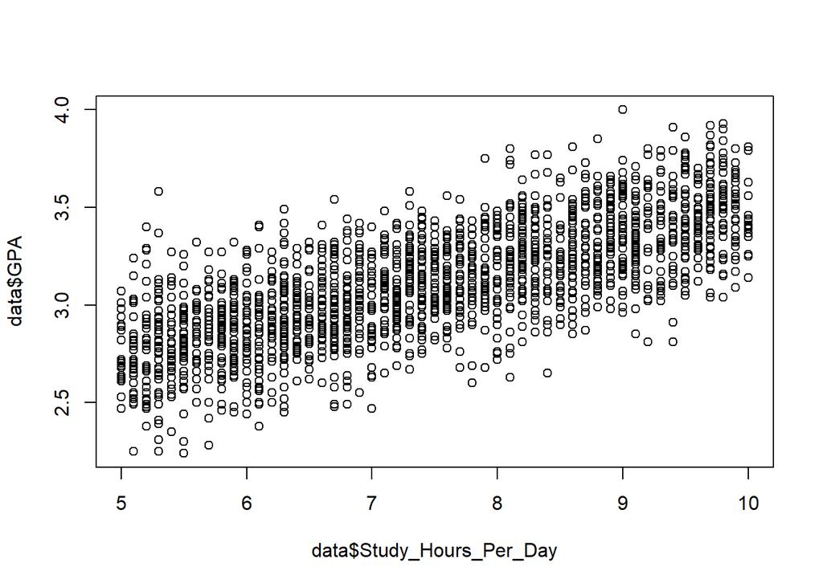

```r
plot(data$Study_Hours_Per_Day, data$GPA)
```

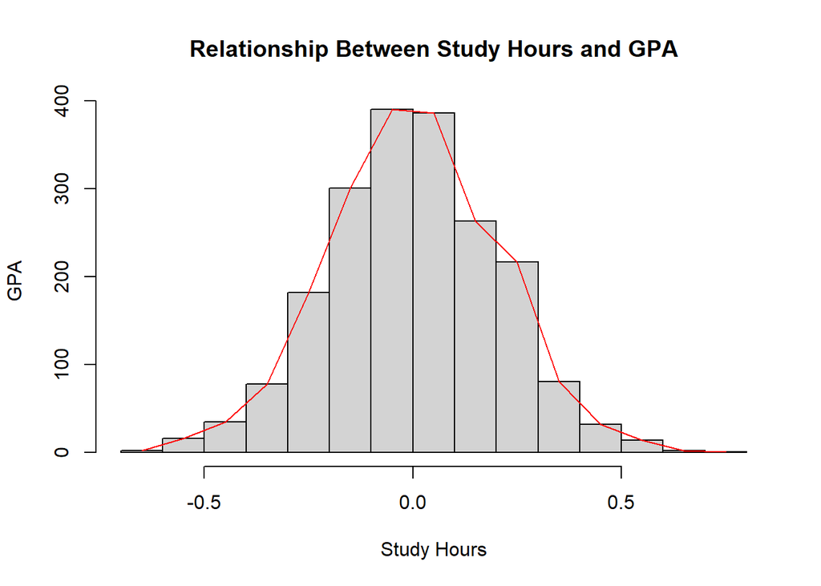

```r
H <- hist(stuGR, plot = FALSE)
hist(stuGR, xlab = "Study Hours",
     ylab = "GPA",
     main = "Relationship Between Study Hours and GPA")
lines(H$mids, H$counts, col = "red")
```

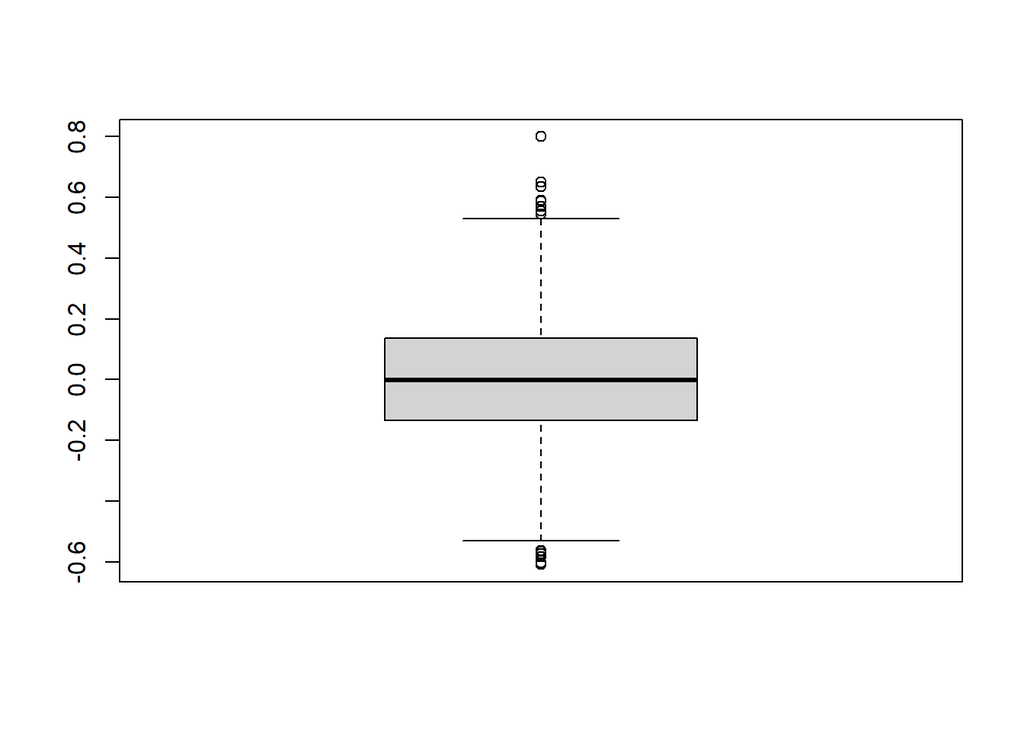

```r
boxplot(stuGR)
```

## Normality Test

### Kolmogorov-Smirnov Test

```r
ks.test(stuGR, pnorm)
```

```
##
##  Asymptotic one-sample Kolmogorov-Smirnov test
##
## data:  stuGR
## D = 0.32461, p-value < 2.2e-16
## alternative hypothesis: two-sided
```

### Lilliefors Test

```r
ks.test((stuGR - mean(stuGR)) / sd(stuGR), pnorm)
```

```
##
##  Asymptotic one-sample Kolmogorov-Smirnov test
##
## data:  (stuGR - mean(stuGR))/sd(stuGR)
## D = 0.017348, p-value = 0.584
## alternative hypothesis: two-sided
```

```r
library(nortest)
lillie.test(stuGR)
```

```
##
##  Lilliefors (Kolmogorov-Smirnov) normality test
##
## data:  stuGR
## D = 0.017348, p-value = 0.1532
```

The null hypothesis is not rejected, indicating that the distribution of residuals is normal.

### Shapiro-Wilk Test

```r
shapiro.test(stuGR)
```

```
##
##  Shapiro-Wilk normality test
##
## data:  stuGR
## W = 0.99907, p-value = 0.4035
```

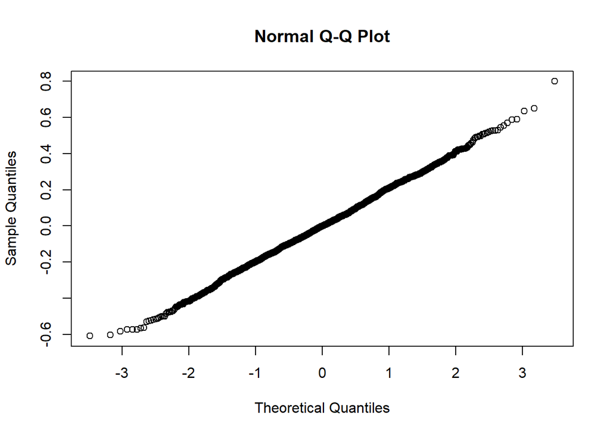

```r
qqnorm(stuGR)
```

In the Shapiro-Wilk test, the null hypothesis is also not rejected, confirming that the residuals follow a normal distribution.

### Anderson-Darling Test

```r
ad.test(stuGR)
```

```
##
##  Anderson-Darling normality test
##
## data:  stuGR
## A = 0.44868, p-value = 0.2778
```

The Anderson-Darling test also supports the conclusion that the residuals are normally distributed.

# Second Fundamental Assumption

It is assumed that the residuals or errors are normally distributed with a mean of zero and constant variance (homoscedasticity). Additionally, the independence of residuals is also evaluated at this level.

## Scatterplot of Predicted Values and Residuals

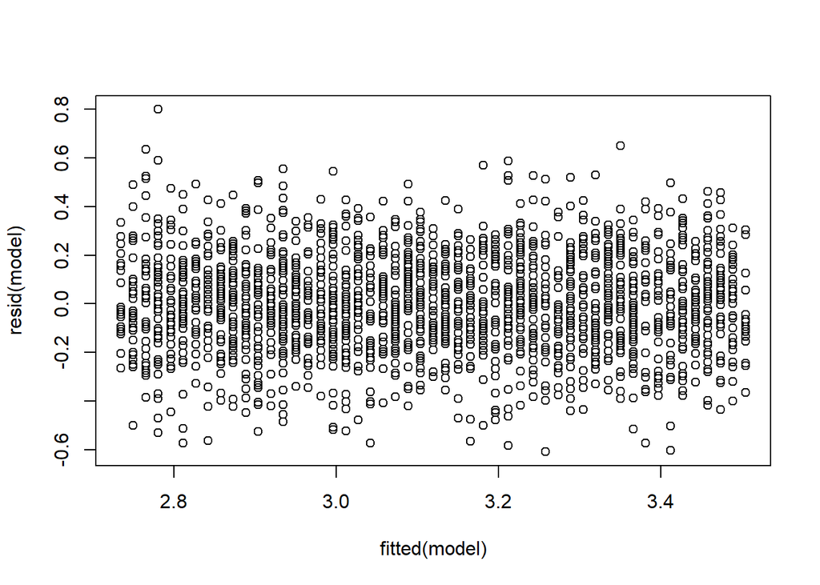

```r
model <- lm(GPA ~ Study_Hours_Per_Day, data = data)
plot(fitted(model), resid(model))
```

The scatterplot does not show a funnel-shaped pattern, and the residuals appear to be randomly distributed. This suggests homoscedasticity (constant variance of errors) in the model.

## Breusch-Pagan Test

```r
anova(model)
```

```
## Analysis of Variance Table
##
## Response: GPA
##                       Df Sum Sq Mean Sq F value    Pr(>F)
## Study_Hours_Per_Day    1 96.195  96.195  2340.2 < 2.2e-16 ***
## Residuals           1998 82.128   0.041
## ---
## Signif. codes:  0 '***' 0.001 '**' 0.01 '*' 0.05 '.' 0.1 ' ' 1
```

```r
bptest(model)
```

```
##
##  studentized Breusch-Pagan test
##
## data:  model
## BP = 0.010588, df = 1, p-value = 0.918
```

The Breusch-Pagan test confirms that the variance of residuals is constant (homoscedasticity is present). This indicates that the linear regression model satisfies this fundamental assumption.

# Third Fundamental Assumption

## Residual Autocorrelation Plot

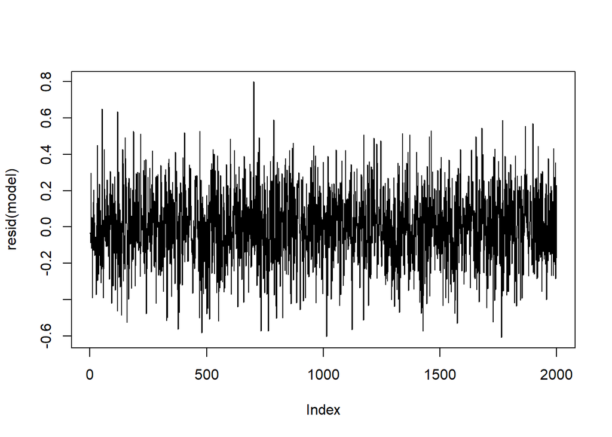

```r
plot(resid(model), type = "l")
```

## Durbin-Watson Test

```r
dwtest(model, alternative = "two.sided")
```

```
##
##  Durbin-Watson test
##
## data:  model
## DW = 2.0038, p-value = 0.9318
## alternative hypothesis: true autocorrelation is not 0
```

```r
durbinWatsonTest(model)
```

```
##  lag Autocorrelation D-W Statistic p-value
##    1    -0.002243624      2.003831   0.904
##  Alternative hypothesis: rho != 0
```